# Mini Proj 3

Saransh Rakshak

Due: 2024-11-19

# Q1: E-Cigarettes

A researcher is studying the efect of e-cigarettes as an aid to smoking cessation. In her study, n = 29 participants with an intention to quiz smoking were given free e-cigarettes and e-liquids for a total of six weeks. They reported their cigarettes smoked per day (CPD) at the beginning of the trial and on a weekly basis for the duration of the study. Some additional characteristics of the participants and their behaviors were also reported.

The file *ecigarettes.csv* gives the cigarettes per day at baseline (CPD BL) and week 6 (CPD W6) for each study participant.

Key question: Do the data suggest that the participants’ cigarettes per day decreased over the course of the study?

Use statistical methods to address the key question. **In your conclusion, include a brief discussion of this question in addition to other required components: based on the information provided, does this study design allow for effective evaluation of whether e-cigarette usage leads to decreased cigarettes per day? Why or why not?

#### Part 1. A brief descriptive summary of the data that addresses the key question. Include summary statistics and an appropriate plot or table. For full credit, make sure your calculations are integrated into the text. Give your description in paragraph form.

```r
ecig <- ecig %>%
  mutate(CPD_diff = CPD_BL - CPD_W6)

summary(ecig)
```

```
##    recordid             CPD_BL          CPD_W6          age
##  Length:29          Min.   : 6.00   Min.   : 5.00   Length:29
##  Class :character   1st Qu.:18.00   1st Qu.:17.00   Class :character
##  Mode  :character   Median :29.00   Median :25.00   Mode  :character
##                     Mean   :24.17   Mean   :23.17
##                     3rd Qu.:31.00   3rd Qu.:31.00
##                     Max.   :35.00   Max.   :37.00
##    adherence         CPD_diff
##  Min.   :0.0000   Min.   :-3
##  1st Qu.:1.0000   1st Qu.: 0
##  Median :1.0000   Median : 1
##  Mean   :0.7586   Mean   : 1
##  3rd Qu.:1.0000   3rd Qu.: 2
##  Max.   :1.0000   Max.   : 5
```

```r
summary_ecigs <- ecig %>%
  summarise(
    mean_CPD_BL = mean(CPD_BL),
    sd_CPD_BL = sd(CPD_BL),
    mean_CPD_W6 = mean(CPD_W6),
    sd_CPD_W6 = sd(CPD_W6),
    mean_diff = mean(CPD_diff),
    sd_diff = sd(CPD_diff)
  )

summary_ecigs
```

```
##   mean_CPD_BL sd_CPD_BL mean_CPD_W6 sd_CPD_W6 mean_diff  sd_diff
## 1    24.17241  8.996305    23.17241  9.250749         1 2.251983
```

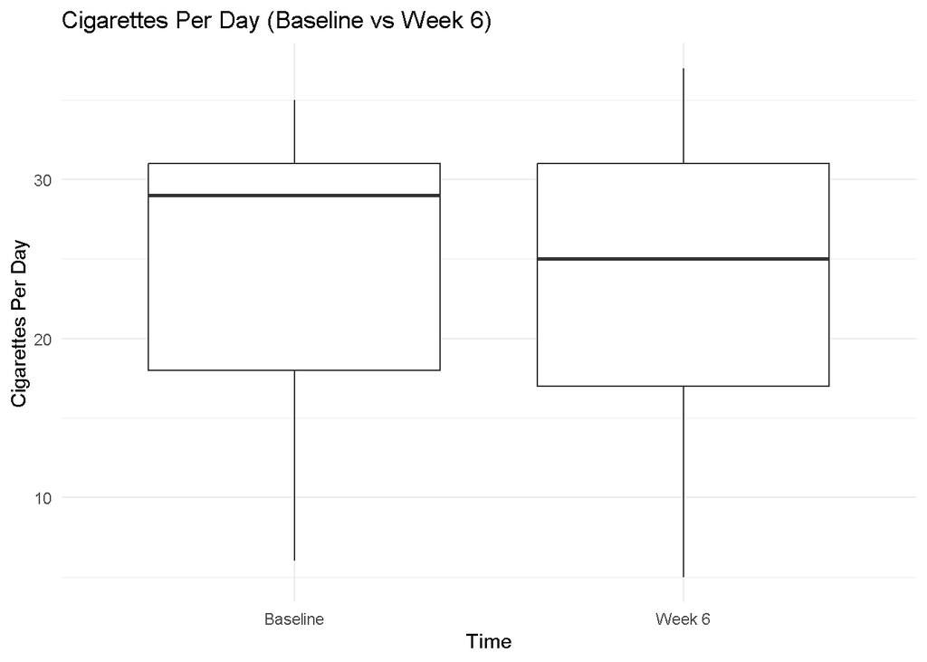

```r
boxplot_data <- data.frame(
  Time = rep(c("Baseline", "Week 6"), each = nrow(ecig)),
  CPD = c(ecig$CPD_BL, ecig$CPD_W6)
)

ggplot(boxplot_data, aes(x = Time, y = CPD)) +
  geom_boxplot() +
  labs(title = "Cigarettes Per Day (Baseline vs Week 6)",
       x = "Time",
       y = "Cigarettes Per Day") +
  theme_minimal()
```

The boxplot indicates a slight drop in the median number of cigarettes per day from baseline to week 6. This is confirmed by our summary table where our baseline mean *mean_CPD_BL* = 24.17241 is slightly higher than at 6 weeks later (23.17241). However, the variability (as seen from the spread of data) overlaps significantly between baseline and week 6 - suggesting that the observed decrease might not be strong or consistent across participants. Furthermore we can see that our dataset is very small (Length:29), adding to its unreliability.

#### Part 2. An appropriate inferential analysis to address the key question. This may be a confidence interval, hypothesis test, or both. You may use the $\alpha$ value/confidence level of your choosing. If you perform a hypothesis test, state the hypotheses, test statistic, p-value, decision, and conclusion. If you create a confidence interval, state the confidence level and provide an interpretation of the interval.

We will now perform a paired *t-test* to see if the mean difference in cigarettes per day (CPD) between baseline and week 6 is statistically significant. We will utilize a moderate alpha value of 0.05 ($\alpha = 0.05$), and establish our hypothesis as follows…

- *Null Hypothesis*: There is no decrease in the mean number of cigarettes per day from baseline to week 6. (CPD_BL - CPD_W6 <= 0).

$$H_0: \mu_C = 0$$

- *Alternative Hypothesis*: There is a decrease in the mean number of cigarettes per day from baseline to week 6. (CPD_BL - CPD_W6 > 0).

```r
# One-tailed t Test
t.test(ecig$CPD_BL, ecig$CPD_W6, paired = TRUE, alternative = "less")
```

```
##
##  Paired t-test
##
## data:  ecig$CPD_BL and ecig$CPD_W6
## t = 2.3913, df = 28, p-value = 0.9881
## alternative hypothesis: true mean difference is less than 0
## 95 percent confidence interval:
##      -Inf 1.711384
## sample estimates:
## mean difference
##               1
```

#### Part 3. A thoughtful conclusion based on the information presented in items 1-3. The conclusion should summarize your findings with respect to the key question. You should also discuss any limitations or complications of your analysis.

Based on the information provided, the study design does not appear to be sufficiently robust to effectively evaluate whether e-cigarette usage leads to a decrease in cigarettes per day for the following reasons…

```
A. Sample Size: The study involved a relatively small sample of 29 participants, which can lead to high variability and limits the generalizability of the findings. A larger sample size would provide more statistical power, potentially allowing for the detection of smaller but meaningful differences.

B. Duration: The time frame for observation was from baseline to week 6. A longer study period might be necessary to capture long-term trends and more substantial changes in smoking behavior, especially if the impact of e-cigarette usage takes time to manifest. Extending the study duration would allow for observation of longer-term trends in smoking behavior.

C. Lack of Control Group: The study design did not mention the presence of a control group. A control group of participants who did not use e-cigarettes would provide a baseline for comparison to determine if observed changes are genuinely attributable to e-cigarette use or due to other factors.

D. Confounding Factors: The study did not appear to account for potential confounding factors (e.g., motivation to quit, social influences, or other smoking cessation aids) that might impact cigarette consumption independently of e-cigarette use. Without controlling for these factors, it’s challenging to attribute any changes in smoking behavior solely to e-cigarette use.
```

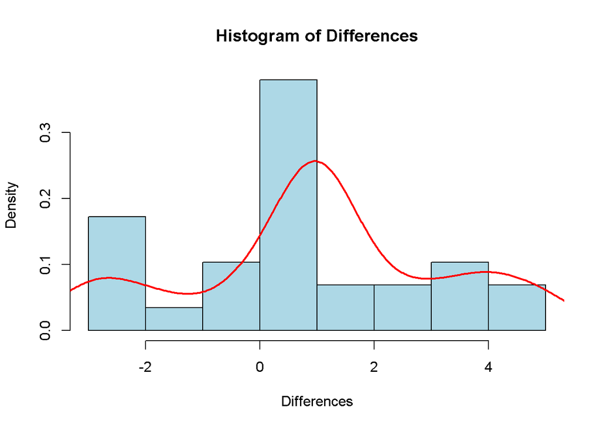

```r
ecig$difference <- ecig$CPD_BL - ecig$CPD_W6

hist(
  ecig$difference,
  main = "Histogram of Differences",
  xlab = "Differences",
  col = "lightblue",
  border = "black",
  freq = FALSE # plot density
)

lines(density(ecig$difference), col = "red", lwd = 2)
```

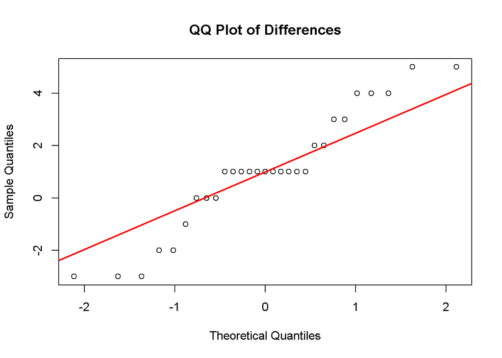

```r
qqnorm(ecig$difference, main = "QQ Plot of Differences")
qqline(ecig$difference, col = "red", lwd = 2) # Add a reference line
```

Based on our histogram, the differences do not visually appear to follow a normal distribution as it does not appear to be symmetric or bell-shaped. Instead, it shows:

```
- A noticeable concentration of values around 0.
- A potential skewness (as the distribution seems slightly unbalanced).
```

# Q2: Heifer Feed

A team of animal science researchers want to investigate the effects of different supplemental feeding methods on young heifers. In this study, all cows in an experimental farm were randomly assigned to be given a feed supplement either from a shared trough with other cows (Treatment=Group) or from an automatic precision feeder that dispensed a pre-determined amount to each heifer as it approached the feeder (Treatment=Precision). The supplements were given at two levels, 0.5% and 1% of the cows’ bodyweights.

The cows’ weights (lbs) were measured once a month for about 6 months. The weights and identifiers for each cow are found in the data set *heifer_mod.csv*. The researchers are interested in seeing how the total weight gain (tgain) differs across the two types of feeding methods.

Key question: On average, did cows using Group feeding have a different total weight gain than cows using the Precision feeding in the low feed level (level=0.5)? What about in the high feed level (level=1)?

(Perform the descriptive and inferential analyses separately for the two levels.)

#### Part 1. A brief descriptive summary of the data that addresses the key question. Include summary statistics and an appropriate plot or table. For full credit, make sure your calculations are integrated into the text. Give your description in paragraph form.

```r
# Subset by feed level (0.5 or 1.0)
level_05 <- heifer %>% filter(level == 0.5)
level_1 <- heifer %>% filter(level == 1.0)

# Subset by feed method (group or precision)
group_05 <- level_05 %>% filter(Treatment == "GROUP") %>% select(tgain)
precision_05 <- level_05 %>% filter(Treatment == "PRECISION") %>% select(tgain)

group_1 <- level_1 %>% filter(Treatment == "GROUP") %>% select(tgain)
precision_1 <- level_1 %>% filter(Treatment == "PRECISION") %>% select(tgain)
```

```r
# Summary stats for tgain
summary_stats <- heifer %>%
  group_by(level, Treatment) %>%
  summarize(
    Mean = mean(tgain, na.rm = TRUE),
    Median = median(tgain, na.rm = TRUE),
    SD = sd(tgain, na.rm = TRUE),
    Min = min(tgain, na.rm = TRUE),
    Max = max(tgain, na.rm = TRUE),
    .groups = "drop"
  )

summary_stats
```

```
## # A tibble: 4 × 7
##   level Treatment  Mean Median    SD   Min   Max
##   <dbl> <chr>     <dbl>  <dbl> <dbl> <dbl> <dbl>
## 1   0.5 GROUP      185.   182.  35.7 128.   271.
## 2   0.5 PRECISION  129.   126.  49.9  77.5  274.
## 3   1   GROUP      198.   217   49.1  97.2  282.
## 4   1   PRECISION  226.   203.  48.7 159.   309.
```

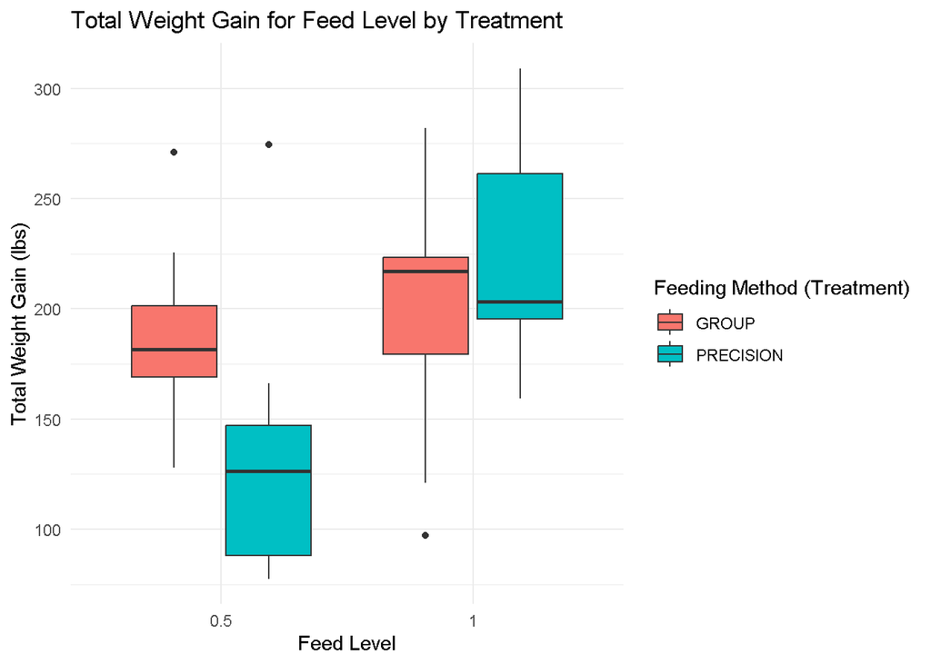

```r
ggplot(heifer, aes(x = factor(level), y = tgain, fill = Treatment)) +
  geom_boxplot() +
  labs(
    title = "Total Weight Gain for Feed Level by Treatment",
    x = "Feed Level",
    y = "Total Weight Gain (lbs)"
  ) +
  scale_fill_discrete(name = "Feeding Method (Treatment)") +
  theme_minimal()
```

#### Part 2. An appropriate inferential analysis to address the key question. This may be a confidence interval, hypothesis test, or both. You may use the $\alpha$ value/confidence level of your choosing. If you perform a hypothesis test, state the hypotheses, test statistic, p-value, decision, and conclusion. If you create a confidence interval, state the confidence level and provide an interpretation of the interval.

We will now use hypothesis testing to answer our Key Question. We will use a *t-test* for the following reasons:

```
A. The t-test directly assesses differences in means - what we are searching for.

B. Total weight gain (tgain) is a continuous dependent variable.

C. The feeding methods represent two independent groups.

D. The sample sizes are moderately large, enough to support the assumption of approximate normality by CLT.
```

We will establish our Null and Alternative Hypothesis for **both** feeding levels (0.5% or 1.0%) as follows…

- *Null Hypothesis*: There is no difference in total weight gain between the Group and Precision feeding methods.

$$H_0: \mu_{Group} =
\mu_{Precision}$$

- *Alternative Hypothesis*: There is a difference in total weight gain between the Group and Precision feeding methods.

$$H_A: \mu_{Group} \neq
\mu_{Precision}$$

**1. Low Feed Levels (0.05%)**

```r
# Perform t-test for 0.5% feed level
t.test(group_05, precision_05, var.equal = FALSE)
```

```
##
##  Welch Two Sample t-test
##
## data:  group_05 and precision_05
## t = 3.6074, df = 25.237, p-value = 0.001333
## alternative hypothesis: true difference in means is not equal to 0
## 95 percent confidence interval:
##  24.27326 88.79674
## sample estimates:
## mean of x mean of y
##   185.075   128.540
```

- Test Statistic: 3.6074
- P-Value: 0.001333
- 95% Confidence Interval: [24.27326, 88.79674]
- Means:
  - Group feeding: 185.075
  - Precision feeding: 128.540
- Decision: We will reject the Null Hypothesis and conclude, on average, cows fed using the Group method had a statistically significantly higher total weight gain than those fed using the Precision method at the low 0.5% feed level.
- Reasoning: Since our P-Value of 0.001333 is lower than our $\alpha$ = 0.05, we reject the null hypothesis. Also the confidence interval [24.27326, 88.79674] not including 0, further supports that there is a statistically significant difference in total weight gain between the feeding methods at the low 0.5% feed level.

**2. High Feed Levels (1.0%)**

```r
# Perform t-test for 1% feed level
t.test(group_1, precision_1, var.equal = FALSE)
```

```
##
##  Welch Two Sample t-test
##
## data:  group_1 and precision_1
## t = -1.6387, df = 29.998, p-value = 0.1117
## alternative hypothesis: true difference in means is not equal to 0
## 95 percent confidence interval:
##  -63.696632   6.984132
## sample estimates:
## mean of x mean of y
##  197.9062  226.2625
```

- Test Statistic: -1.6387
- P-Value: 0.1117
- 95% Confidence Interval: [-63.696632, 6.984132]
- Means:
  - Group feeding: 197.9062
  - Precision feeding: 226.2625
- Decision: We will fail to reject the Null Hypothesis and conclude, on average, cows fed using the Group method did not have a statistically significantly higher total weight gain than those fed using the Precision method at the high 1.0% feed level.
- Reasoning: Since our P-Value of 0.1117 is greater than our $\alpha$ = 0.05, we fail to reject the null hypothesis. Also the confidence interval [-63.696632, 6.984132] includes 0, indicating that the observed difference in means is not statistically significant. Thus we can conclude at the 1.0% feed level, there is no significant difference in total weight gain between cows using the Group and Precision feeding methods.

#### Part 3. A thoughtful conclusion based on the information presented in items 1-3. The conclusion should summarize your findings with respect to the key question. You should also discuss any limitations or complications of your analysis.

Conclusion: For Low Feed Levels (0.5%) the Group feeding method is superior in terms of total weight gain. Cows using the Group feeding method gained significantly more weight than those using the Precision method. This result suggests that at lower feed levels, shared feeding may encourage greater intake or weight gain compared to individually dispensed feed.

For High Feed Levels (1.0%) the choice of feeding method does not make a significant difference. There was no significant difference in total weight gain between the two feeding methods. At higher feed levels, the precision of the dispensing method may not substantially affect weight gain, potentially due to sufficient overall feed availability.

One limitation of our analysis was the representativeness of the data from *heifer_mod.csv*, which consists of data from a single experimental farm. This brings issues for the generalizability of our findings. If the cows, feeding methods, and environmental conditions are not representative of a broader population of heifers or farms, the conclusions may not be widely applicable. Random assignment of cows to feeding methods helps mitigate bias, but any underlying systematic differences such as breed or health status not accounted for could affect the results.

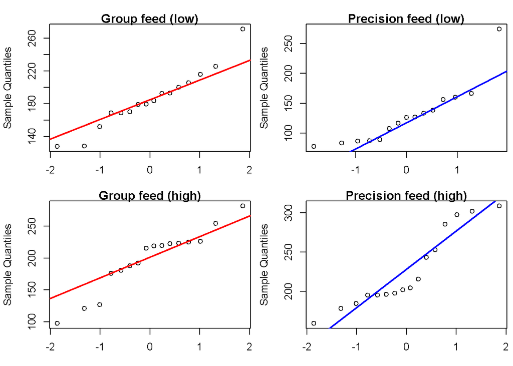